# OLS Regression

## Overview

Demonstrates how a linear regression model can be fitted in R. Given a data set ${\{y_{i},\,x_{i1},\ldots ,x_{ip}\}_{i=1}^{n}}$ of n statistical units, the model takes the form:
$$y_{i}=\beta _{1}x_{i1}+\cdots +\beta _{p}x_{ip}+\varepsilon _{i}=\mathbf {x} _{i}^{\rm {T}}{\boldsymbol {\beta }}+\varepsilon _{i},\qquad i=1,\ldots ,n,$$
where,
$y_{i}$ is the response variable,
$x_{i1},\,x_{i2},\,\ldots ,\,x_{ip}$ are the regressors,
$\beta$ is a p-dimensional parameter vector (estimated by least-squares method)
$\epsilon_{i}$ is the error term.

## Dataset

A simulated data set containing sales of child car seats at 400 different stores.

- **Sales**: Unit sales (in thousands) at each location
- **CompPrice**: Price charged by competitor at each location
- **Income**: Community income level (in thousands of dollars)
- **Advertising**: Local advertising budget for company at each location (in thousands of dollars)
- **Price**: Price company charges for car seats at each site
- **ShelveLoc**: A factor with levels Bad, Good and Medium indicating the quality of the shelving location for the car seats at each site
- **Age**: Average age of the local population

```r
head(model.data)
```

```
##   Sales CompPrice Income Advertising Price ShelveLoc Age
## 1  9.50       138     73          11   120       Bad  42
## 2 11.22       111     48          16    83      Good  65
## 3 10.06       113     35          10    80    Medium  59
## 4  7.40       117    100           4    97    Medium  55
## 5  4.15       141     64           3   128       Bad  38
## 6 10.81       124    113          13    72       Bad  78
```

## Fitting the Model

We will regress the *Sales* variable onto *CompPrice, Income, Advertising, Price, ShelveLoc, and Age*. A linear model is fitted by least-squares, which minimizes the sum of squared residuals and leads to a closed-form expression for the estimated value of the unknown parameter $\boldsymbol \beta$.

Objective:
$${\hat {\boldsymbol {\beta }}}={\rm {arg}}\min _{\boldsymbol \beta }\,\lVert \mathbf {y}-\mathbf {X}{\boldsymbol \beta } \rVert ,$$

which leads to:
$${\hat {\boldsymbol {\beta }}}=(\mathbf {X} ^{\rm {T}}\mathbf {X} )^{-1}\mathbf {X} ^{\rm {T}}\mathbf {y} ={\big (}\,{\textstyle \sum }\mathbf {x} _{i}\mathbf {x} _{i}^{\rm {T}}\,{\big )}^{-1}{\big (}\,{\textstyle \sum }\mathbf {x} _{i}y_{i}\,{\big )}.$$

```r
model <- lm(Sales ~ CompPrice + Income + Advertising + Price +
              ShelveLoc + Age, data = model.data)
model$coefficients
```

```
##     (Intercept)       CompPrice          Income     Advertising
##      5.47522623      0.09257147      0.01578497      0.11590340
##           Price   ShelveLocGood ShelveLocMedium             Age
##     -0.09531895      4.83567475      1.95199266     -0.04612752
```

Adjusted R-squared: 0.8696965  
F-statistic: 381.4401831

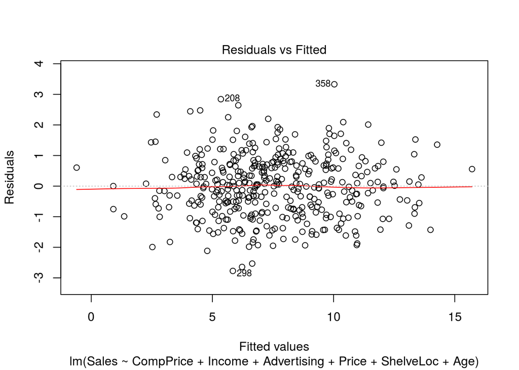

```r
# sales vs predicted sales
head(data.frame(Sales = model.data$Sales, PredictedSales = predict(model)), 10)
```

```
##    Sales PredictedSales
## 1   9.50       7.301699
## 2  11.22      12.288705
## 3  10.06       9.252263
## 4   7.40       8.517239
## 5   4.15       5.932080
## 6  10.81       9.783623
## 7   6.63       6.160859
## 8  11.85      11.388936
## 9   6.54       6.057758
## 10  4.69       6.105112
```